# Machine Learning of Qualitative Human Activity

John Akwei, ECMp ERMp

Wednesday, April 15, 2015

#### Synopsis:

This document incorporates the activity monitoring device data from “http://groupware.les.inf.puc-rio.br/har”, in order to predict the manner in which the test subjects performed a dumbbell lifting exercise. If the data from this document is used for any other research, please cite the preceding source because of generosity of data distribution.

The data includes Euler angles, accelerometer, gyroscope, and magnetometer readings. The variable to predict is “classe”, (involving 1 correct exercise and 4 types of exercise mistakes), and ranges from A to E.

Further information on the data in this document is at: “Velloso, E.; Bulling, A.; Gellersen, H.; Ugulino, W.; Fuks, H. Qualitative Activity Recognition of Weight Lifting Exercises. Proceedings of 4th International Conference in Cooperation with SIGCHI (Augmented Human ’13) . Stuttgart, Germany: ACM SIGCHI, 2013.”

The training data source is at “https://d396qusza40orc.cloudfront.net/predmachlearn/pml-training.csv”. The test data source is at “https://d396qusza40orc.cloudfront.net/predmachlearn/pml-testing.csv”.

#### Required Packages:

```r
#setwd("C:/Users/johnakwei/Desktop/Coursera/PracticalMachineLearning/CourseProjectWriteUp")
if (!require("plyr")) { install.packages("plyr"); require("plyr") }
if (!require("caret")) { install.packages("caret"); require("caret") }
if (!require("rpart")) { install.packages("rpart"); require("rpart") }
if (!require("randomForest")) { install.packages("randomForest"); require("randomForest") }
if (!require("e1071")) { install.packages("e1071"); require("e1071") }
```

#### Data Input:

```r
training <- read.csv("pml-training.csv", na.strings=c("","NA","NULL"))
testing <- read.csv("pml-testing.csv", na.strings=c("","NA","NULL"))
```

#### Data Cleaning:

```r
training <- training[, colSums(is.na(training))==0]
testing <- testing[, colSums(is.na(testing))==0]
training <- training[, c(8:60)]
testing <- testing[, c(8:60)]
```

#### Cross Validation:

The dataset is divided into 70% training data and 30% testing data:

```r
inTrain <- createDataPartition(y=training$classe, p=0.70, list=F)
train <- training[inTrain,]
test <- training[-inTrain,]
```

#### Plot of Quantitive Data Gathering:

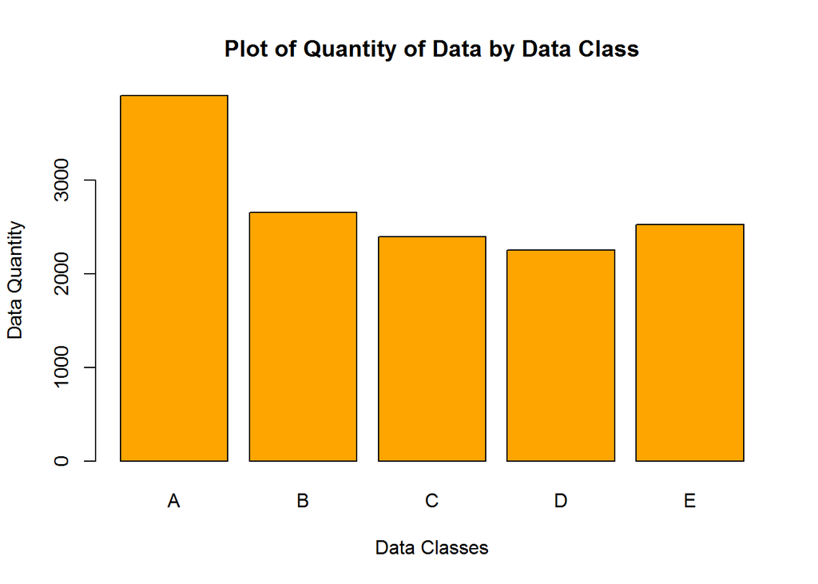

```r
plot(train$classe, col="orange", main="Plot of Quantity of Data by Data Class", xlab="Data Classes", ylab="Data Quantity")
```

#### Decision Tree Prediction Model:

```r
model <- rpart(classe~., data=train, method="class")
prediction  <- predict(model, test, type="class")
confusionMatrix(prediction, test$classe)
```

```
## Confusion Matrix and Statistics
##
##           Reference
## Prediction    A    B    C    D    E
##          A 1495  238   20   86   23
##          B   31  538   47   21   50
##          C   53  171  855   83   92
##          D   63   62   73  667   76
##          E   32  130   31  107  841
##
## Overall Statistics
##
##                Accuracy : 0.747
##                  95% CI : (0.7357, 0.7581)
##     No Information Rate : 0.2845
##     P-Value [Acc > NIR] : < 2.2e-16
##
##                   Kappa : 0.6791
##  Mcnemar's Test P-Value : < 2.2e-16
##
## Statistics by Class:
##
##                      Class: A Class: B Class: C Class: D Class: E
## Sensitivity            0.8931  0.47234   0.8333   0.6919   0.7773
## Specificity            0.9128  0.96861   0.9179   0.9443   0.9375
## Pos Pred Value         0.8029  0.78311   0.6818   0.7088   0.7371
## Neg Pred Value         0.9555  0.88438   0.9631   0.9399   0.9492
## Prevalence             0.2845  0.19354   0.1743   0.1638   0.1839
## Detection Rate         0.2540  0.09142   0.1453   0.1133   0.1429
## Detection Prevalence   0.3164  0.11674   0.2131   0.1599   0.1939
## Balanced Accuracy      0.9030  0.72047   0.8756   0.8181   0.8574
```

#### Random Forest Prediction Model:

```r
model2 <- randomForest(classe~., data=train, na.action=na.omit)
prediction2 <- predict(model2, test, type="class")
result2 <- confusionMatrix(prediction2, test$classe)
result2
```

```
## Confusion Matrix and Statistics
##
##           Reference
## Prediction    A    B    C    D    E
##          A 1674    4    0    0    0
##          B    0 1134    6    0    0
##          C    0    1 1020    8    0
##          D    0    0    0  954    2
##          E    0    0    0    2 1080
##
## Overall Statistics
##
##                Accuracy : 0.9961
##                  95% CI : (0.9941, 0.9975)
##     No Information Rate : 0.2845
##     P-Value [Acc > NIR] : < 2.2e-16
##
##                   Kappa : 0.9951
##  Mcnemar's Test P-Value : NA
##
## Statistics by Class:
##
##                      Class: A Class: B Class: C Class: D Class: E
## Sensitivity            1.0000   0.9956   0.9942   0.9896   0.9982
## Specificity            0.9991   0.9987   0.9981   0.9996   0.9996
## Pos Pred Value         0.9976   0.9947   0.9913   0.9979   0.9982
## Neg Pred Value         1.0000   0.9989   0.9988   0.9980   0.9996
## Prevalence             0.2845   0.1935   0.1743   0.1638   0.1839
## Detection Rate         0.2845   0.1927   0.1733   0.1621   0.1835
## Detection Prevalence   0.2851   0.1937   0.1749   0.1624   0.1839
## Balanced Accuracy      0.9995   0.9972   0.9961   0.9946   0.9989
```

#### Expected Out-Of-Sample Error Rate:

```r
OutErrorRate <- 1 - result2[["overall"]][["Accuracy"]]
OutErrorRate
```

```
## [1] 0.003908241
```

#### Output files:

The output files chosen were from the Random Forest algorithm:

```r
predictionResult <- predict(model2, testing, type="class")
predictionResult
```

```
##  1  2  3  4  5  6  7  8  9 10 11 12 13 14 15 16 17 18 19 20
##  B  A  B  A  A  E  D  B  A  A  B  C  B  A  E  E  A  B  B  B
## Levels: A B C D E
```

#### Conclusion:

The machine learning algorithm with the highest accuracy is the Random Forest model with 99.6% accuracy, and a 0.39% Out of Sample Error Rate. However, the level of over fitting with the Random Forest prediction model might not scale for other data.